# Arctic fox

[NO_AFOX_001]

Author

Affiliation

Anders Kolstad

The Norwegian Institute for Nature Research (NINA)

Published

July 1, 2026

Reviewed by

Matthew Grainger

> **Recommended citation**: Kolstad, A. 2026. Arctic fox [Fjellrev] (ID(s): NO_AFOX_001) v. 1.0.0. ecRxiv: https://github.com/NINAnor/ecRxiv/tree/main/indicators/NO_AFOX_001

**TipMetadata**

Table 1: Indicator metadata

| Variable | Value |
| --- | --- |
| Indicator ID | NO_AFOX_001 |
| Indicator Name | Arctic fox [Fjellrev] |
| verbatimName | Fjellrev |
| Country | Norway |
| Continent | Europe |
| Ecosystem Condition Typology Class | B1 - Compositional state characteristics |
| Realm | Terrestrial (T) |
| Biome | T6 Polar-alpine (cryogenic) biome |
| Ecosystem | NA |
| verbatimEcosystem | Fjell |
| Year added | 2026 |
| Last update | 2026 |
| Version | 1.0.0 |
| Version comment | First version on ecRxiv, but this indicator is already published and described in the Norwegian Nature Index |
| Normalised | TRUE |
| Spatial aggregation pathway | [Scale - Truncate] - Aggregate (geographic region) - aggregate (Norway) |
| Precision | Uncertainties around the estimated true value reported as probability distributions and 95% confidence intervals. |

**TipLog**

- May 27 2026 - submission
- July 1 2026 - Accepted

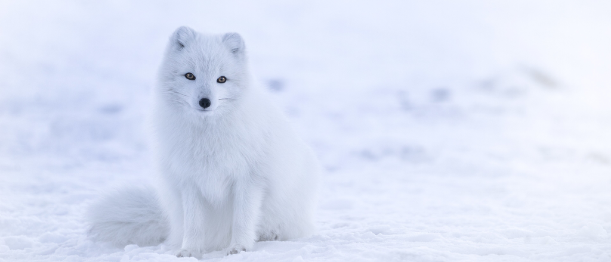

Figure 1: Arctic fox (photo: Jonathen Pie, CC0, via Wikimedia Commons)

## 1. Summary

1. **Background and rationale**: Arctix fox is an alpine specialist. The populations today are small and fragmented due to past overhunting. Arctic fox is sensitive to climate change, perhaps mostly indirectly so, as wetter and warmer winters are causing a decline in rodent numbers, it’s main food source. It is also negatively affected by competition with the red fox, and by the effects of having small and isolated population, and a range of anthopogenic disturbance factors. There is a national breeding program for arctic fox, which is the main reason why we see species recovery in some areas.
2. **Methods**: The arctic fox in Norway has it’s own monitoring program. The data is stored at [rovbase](https://www.rovbase.no/). This program uses DNA sampling and mark-recapture, among other methods (Jackson et al. 2025). We get the data from the Norwegian Nature Index database (Nater and Eriksen 2025).
3. **Interpretation**: An indicator value of 1 means that arctic fox is as numerous, or more, than what we expect under the reference condition. Values decreasing toward zero indicates that the average population size is decreasing.
4. **Results and development needs**: The indicator value for Norway as a whole in 2024 is 0.05 [95% CI = 0.03-0.06]. This is very low and reflects the near extiction of this species from Norwegian alpine ecosystems. There has been some recovery in some local areas due to active intervention (captive breeding).

## 1.2 Native language summary - Norwegian

1. **Bakgrunn og begrunnelse**: Fjellrev er en alpin spesialist. Populasjonene av denne arten i dag er små og fragmenterte som følge av tidligere overbeskatning gjennom jakt. Fjellreven er sårbar for klimaendringer, særlig indirekte ved at våtere og varmere vintre fører til nedgang i smågnagerbestandene, som er dens viktigste matkilde. Den påvirkes også negativt av konkurranse med rødrev, effektene av små og isolerte bestander, samt en rekke menneskeskapte forstyrrelsesfaktorer. Det finnes et nasjonalt avlsprogram for fjellrev, som er hovedårsaken til at vi ser bestandsøkning i enkelte områder.
2. **Metoder**: Fjellrev har sitt eget overvåkingsprogram. Dataene lagres i [rovbase](https://www.rovbase.no/). Programmet benytter blant annet DNA-prøver og fangst-gjennfangst for å estimere bestandsstørrelsen (Jackson et al. 2025). Dataene hentes fra databasen for Naturindeks for Norge (Nater and Eriksen 2025).
3. **Tolkning**: En indikatorverdi på 1 betyr at fjellrevbestanden er like stor eller større enn det vi forventer under referansetilstanden. Verdier som nærmer seg null indikerer at den gjennomsnittlige bestandsstørrelsen på fylkesnivå er avtagende.
4. **Resultater og utviklingsbehov**: Indikatorverdien for hele Norge i 2024 er 0,05 [95 % KI = 0,03–0,06]. Dette er svært lavt og gjenspeiler at arten har vært, og delvis fortsatt er nær utryddelse fra norske alpine økosystemer. Det har vært noe bestandsøkning i enkelte lokale områder som følge av aktive tiltak, særlig gjennom foring, oppdrett og utsetting.

## 2. About the underlying data

We take data from the Norwegian Nature index (Nater and Eriksen 2025). Originally, the data from the arctic fox monitoring is stored at www.rovbase.no, and comes from the national arctic fox monitoring program (Jackson et al. 2025).

### 2.1 Spatial and temporal resolution and extent

Indicator values are available for 1990, 2000, and every year from 2008 to 2024. Each year’s estimate has been averaged out over three years as a moving window.

### 2.2 Sampling design

The arcic fox monitoring program uses a range of methods, including DNA samlping.

### 2.3 Original units

The original units of the raw data is the number of reproducing individuals.

### 2.4 Instructions for citing, using and accessing data

Indicator values from the Norwegian Nature Index can be found in (Nater et al. 2025). Indicator values, variable values and reference values can be downloaded from the Nature Index database using the API, as I have done below. The data is licenced under [CC-BY 4.0](https://creativecommons.org/licenses/by/4.0/).

## 3. Indicator properties

### 3.1 Ecosystem Condition Typology Class (ECT)

B1 - Compositional state characteristics

### 3.2 Ecosystem condition characteristic

The ecosystem characteristic represented in this indicator is an ecosystem where species abundances and composition is similar to that in the reference condition.

### 3.3 Collinearities with other indicators

The arctic fox indicator is assumed to be correlated to the small rodent indicator (NO_ROED_001).

### 3.4 Impact factors

Arctic fox is negatively affected by climate change (esp. through its effect on small rodents). Habitat degradation and land use change also has a negative impact.

### 3.5 Spatial aggregation

The data is available as the scale of municiaplities. At this point I normalise (scale and truncate) the variable. I then aggregate these, first toe the five geographic regions, and then from there, to a national estimate.

## 4. Reference condition and levels

### 4.1 Reference condition

The reference condition is a mountain ecosystem with minimal human impact and a climate similar to the period 1961-1990 (Nybø and Evju (red) 2017).

### 4.2 Reference levels

X<sub>100</sub> is defined for each municiaplity based on the amount of suitable habitat and an assumption on the size of fox territories in habitats of different productivity.

X<sub>0</sub> is defined as a complete absence of arctic fox.

#### 4.2.1 Spatial resolution and validity

The reference values are unique to each municipality.

## 5. Uncertainties

### 5.1 General uncertainties

There is relativity low uncertainty associated with the population estimates or with the reference values.

### 5.2 Reported uncertainties

The reported uncertainties reflect the uncertainties around the true parameter means, i.e. they are inferrential uncertainties for the true value of the indicator for the given area and time combination.

## 6. References

Jackson, C., K. Ulvund, L. Rød-Eriksen, M. W. Furnes, L. Arntsen, T. Mjøen, M. Spets, M. Ø. Jensen, et al. 2025. *Fjellrev i norge 2025. Tiltak, status og anbefalinger*. NINA Rapport 2698. Trondheim: Norsk institutt for naturforskning (NINA).

Nater, C. R., and L. F. Eriksen. 2025. *Naturindeks for Norge 2025. Tilstand og utvikling for biologisk mangfold.* {NINA} {Temahefte} 97. Trondheim: Norsk Institutt for Naturforskning.

Nater, C. R., T. Zeiner-Henriksen, and S. Nybø. 2025. NI2025: Indicator Data. doi:10.21345/y790-v762.

Nybø, S., and M. Evju (red). 2017. *[Fagsystem for fastsetting av god økologisk tilstand - forslag fra et ekspertråd](https://www.regjeringen.no/no/dokumenter/fagsystem-for-fastsetting-av-god-okologisk-tilstand/id2558481/)*.

## 7. Import and prepare datasets

### 7.1 Naturindeks

We download the dataset from the Naturindeks database using the API. The function gives read-only access without requiring a username and password.

```r
# I use a dev version of NIcalc where the username and passwork for the guest user is hard coded into the function. This will probably be merged into the real NIcalc (from NINAnor/NIcalc) soon.
# renv::install("ChloeRN/NIcalc@include_ReadOnly_access")
# library(NIcalc)

# Import data set
afoxImport <- NIcalc::importDatasetApi(
  eco = NULL,
  indic = c("Fjellrev"),
  year = c("2010", "2014", "2019", "2024")
)
saveRDS(afoxImport, here::here("data/afoxImport.rds"))
```

## 8. Spatial units

According to the Naturindeks terminology, the 430 municipalities are called `BSunits`. I use these later just to sum up the total alpine area for some regions. Confusingly, these same municipalities are also called `ICunits`.

The five geographic regions in Norway (east, south, west, central, north) are called `parts`.

We can think of the municipalities as ecosystem assets, and mainland Norway as the Ecosystem accounting Area.

## 9. Analyses

Here I use a generic approach to handling data from the Naturindeks where I get both the variable values and the reference values, separately, from the NI database, and perform the normalisation and spatial aggregation myself.

The variable values have uncertainties in the form of probability function. The uncertainties are from a statistical model, and so we think of them as inferential uncertainties.

Here I use an NIcalc function to just prepare and structure the data a little differently.

```r
# Assemble
assemble <- NIcalc::assembleNiObject(
  inputData = afoxImport,
  predefNIunits = c(allArea = T, parts = T, counties = F),
  indexType = "thematic"
)
```

Then I get the reference values. In the naturindeks, the X<sub>100</sub> is defined with an uncertainty range which we will ignore here. X<sub>0</sub> is a natural zero.

```r
x100 <- afoxImport$referenceValues$referenceValues |>
  select(ICunitId, ICunitName, x100 = expectedValue)
head(x100)
```

```
# A tibble: 6 × 3
  ICunitId ICunitName    x100
     <int> <chr>        <dbl>
1     1164 Rendalen      14.8
2     1165 Tolga         14.8
3     1166 Tynset        14.8
4     1167 Alvdal        11.1
5     1168 Os (Hedmark)  11.1
6     1169 Folldal       25.9
```

The variable values are stored as a parameterised probability function, and I need to draw *n* samples from this function. The probability function differs between indicators in the Naturindeks. It could also differ within an indicator. Here I create a vector defining which probability function to use. I use ´tradObs´ where there is a regular probability distribution family, and `customObs` where customDist!= NA. When `distributionFamilyName == NA`, `customDistribution != NA`.

```r
myYears <- as.character(c(2010, 2014, 2019, 2024))
obstype <- NULL

for (i in 1:length(myYears)) {
  obs <- assemble$indicatorValues[[i]]$distributionFamilyName

  obs[!is.na(obs)] <- "tradObs"
  obs[is.na(obs)] <- "customObs"

  obstype[[i]] <- obs
}
```

Now I am ready to sample the probability distributions. I set *n* to be 1000.

```r
dat <- tibble(ICunitId = NULL, value = NULL, year = NULL)

for (i in 1:length(myYears)) {
  #print(i)
  myMat <- NIcalc::sampleObsMat(
    ICunitId = assemble$indicatorValues[[i]]$ICunitId,
    value = assemble$indicatorValues[[i]]$expectedValue,
    distrib = assemble$indicatorValues[[i]]$distributionFamilyName,
    mu = assemble$indicatorValues[[i]]$distParameter1,
    sig = assemble$indicatorValues[[i]]$distParameter2,
    customDistribution = assemble$indicatorValues[[i]]$customDistribution,
    obsType = obstype[[i]],
    nsim = 1000
  )
  ICunitIds <- row.names(myMat)

  myMat <-  myMat |>
    as_tibble() |>
    add_column(ICunitId = ICunitIds, .before = 1) |>
    pivot_longer(cols = -any_of("ICunitId")) |>
    select(-name) |>
    add_column(year = myYears[i])

  dat <- dat |>
    bind_rows(myMat)
}
head(dat)
```

```
# A tibble: 6 × 3
  ICunitId value year
  <chr>    <dbl> <chr>
1 10301        0 2010
2 10301        0 2010
3 10301        0 2010
4 10301        0 2010
5 10301        0 2010
6 10301        0 2010
```

This is the point in the spatial aggregation where we should normalise against the reference values. So let’s add inn the X<sub>100</sub> values.

```r
dat <- dat |>
  left_join(x100 |> mutate(ICunitId = as.character(ICunitId)), by = join_by(ICunitId))
```

Then we can normalise also the scatter plot with variables against indicator values (Figure 2).

```r
ind <- ec_normalise(
  variable = dat$value,
  x100 = dat$x100
)

dat <- dat |> add_column(indicator = ind)
```

```r
myLim <- max(dat$x100)

temp <- ec_norm_plot(dat$value, dat$indicator) +
  labs(x = "Variable values\n(# reproducing individuals)") +
  xlim(c(0, myLim))
ggsave(here::here("img/norm_plot_eng_afox.png"), scale = 1.5, plot = temp)
```

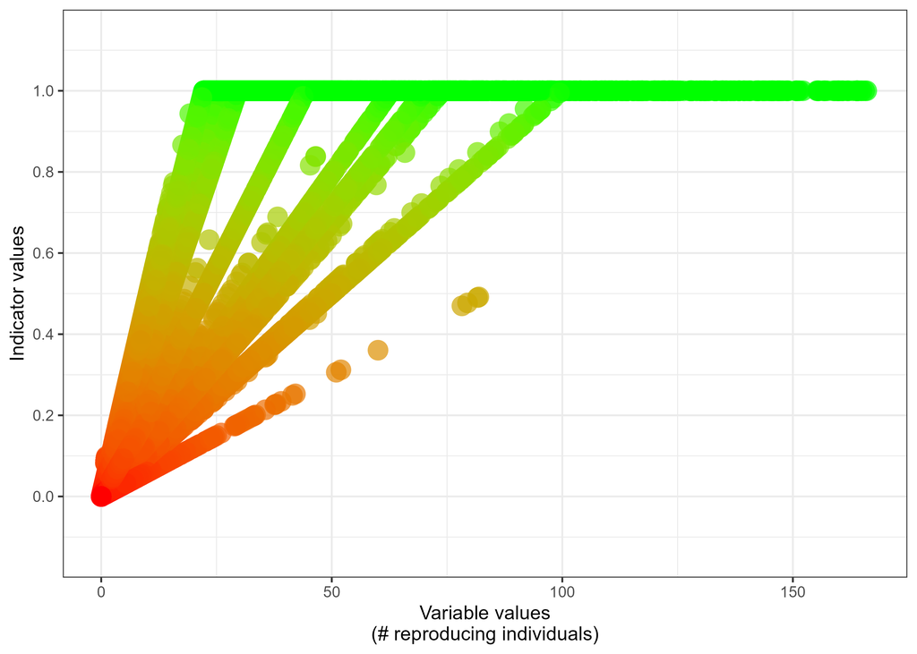

Figure 2: Normalisation (scaling and truncation) of variable values into indicator values. The X100 value differs between municipalities, hence the many lines.

```r
knitr::include_graphics(here::here("img/norm_plot_eng_afox.png"))
```

I also export a figure for the Norwegian fact sheet:

**Export normalisation function plots**

```r
temp <- ec_norm_plot(dat$value, dat$indicator, lan = "norsk") +
  labs(x = "# reproduserende individ", y = "Indikatorverdi", y = "Indikatorverdi") +
  xlim(c(0, myLim))
ggsave(here::here("img/norm_plot_afox.png"), scale =1, plot =temp)
```

### Prepare for agrgegation

Then we can aggregate by a weighted resampling from counties (BSunits or ICunits) to geographic regions (parts), and then to Norway. For this we need to know which geographic region (N, M, E, S, W) the ICunits belong to.

```r
# In this object we get the rows per municipality (BSunits), with mountain area ("Fjell") and geographic region ("part").
aux <- as_tibble(assemble$BSunits) |>
  rename(BSunitId = id)
head(aux)
```

```
# A tibble: 6 × 10
  BSunitId Fjell name         totalArea terrestrialArea marineArea county  part
     <int> <dbl> <chr>            <dbl>           <dbl>      <dbl> <chr>   <chr>
1      432  800. Rendalen         3180.           3180.          0 Hedmark E
2      436  462. Tolga            1124.           1124.          0 Hedmark E
3      437  644. Tynset           1880.           1880.          0 Hedmark E
4      438  318. Alvdal            943.            943.          0 Hedmark E
5      439  651. Folldal          1279.           1279.          0 Hedmark E
6      441  402. Os (Hedmark)     1040.           1040.          0 Hedmark E
# ℹ 2 more variables: centerLat <dbl>, centerLong <dbl>
```

We can add the ICunitId into here.

```r
IC_BC_link <- afoxImport$ICunits |>
  select(ICunitId = id, BSunitId)

aux <- aux |>
  left_join(IC_BC_link, by = join_by(BSunitId))
```

Then we can move this information into the main dataset. We use the alpine area that is recorded in the Naturindeks database. They should represent the area above the empirical forest line.

```r
dat2 <- dat |>
  left_join(
    aux |>
      select(ICunitId, part, Fjell) |>
      mutate(ICunitId = as.character(ICunitId)),
    by = join_by(ICunitId)
  )
head(dat2)
```

```
# A tibble: 6 × 8
  ICunitId value year  ICunitName  x100 indicator part  Fjell
  <chr>    <dbl> <chr> <chr>      <dbl>     <dbl> <chr> <dbl>
1 10301        0 2010  Røros       11.1         0 C      573.
2 10301        0 2010  Røros       11.1         0 C      573.
3 10301        0 2010  Røros       11.1         0 C      573.
4 10301        0 2010  Røros       11.1         0 C      573.
5 10301        0 2010  Røros       11.1         0 C      573.
6 10301        0 2010  Røros       11.1         0 C      573.
```

### Spatial aggregation

Then we can aggregate from municipalities to regions. I use `ecTools` for this. This uses a Monte Carlo propagation of the uncertainties.

```r
mc_propagated_afox <- ecTools::ec_upscale(
  data = dat2,
  variable = indicator,
  weight = Fjell,
  start_units = ICunitId,
  end_units = part,
  year = year,
  end_units_name = "part",
  n = 1000
)

saveRDS(mc_propagated_afox, here::here("data/mc_propagated_afox.rds"))
```

Then we aggregate to all of Norway, but first we get the summed alpine area per region.

```r
aux_2 <- aux |>
  group_by(part) |>
  summarise(Fjell = sum(Fjell))

# add it to the data
mc_propagated_afox <- mc_propagated_afox |>
  left_join(aux_2, by = join_by(part)) |>
  add_column(end_units = "Norway")
```

```r
mc_propagated_afox2 <- ecTools::ec_upscale(
  data = mc_propagated_afox,
  variable = sampled_mean,
  weight = Fjell,
  start_units = part,
  end_units = end_units,
  year = year,
  end_units_name = "part",
  n = 1000
)

saveRDS(mc_propagated_afox2, here::here("data/mc_propagated_afox2.rds"))
```

Then we append this to the main dataset

```r
out <- mc_propagated_afox |>
  bind_rows(mc_propagated_afox2)

out |> count(year, part)
```

```
# A tibble: 24 × 3
   year  part       n
   <chr> <chr>  <int>
 1 2010  C       1000
 2 2010  E       1000
 3 2010  N       1000
 4 2010  Norway  1000
 5 2010  S       1000
 6 2010  W       1000
 7 2014  C       1000
 8 2014  E       1000
 9 2014  N       1000
10 2014  Norway  1000
# ℹ 14 more rows
```

## 10. Results

Then we create some summary statistics (Table 2) and plot them (Figure 3).

```r
summary_out <- out |>
  group_by(part, year) |>
  summarise(
    median = round(median(sampled_mean), 2),
    p_025 = round(quantile(sampled_mean, probs = 0.025), 2),
    p_25 = round(quantile(sampled_mean, probs = 0.25), 2),
    p_75 = round(quantile(sampled_mean, probs = 0.75), 2),
    p_975 = round(quantile(sampled_mean, probs = 0.975), 2),
  ) |>
  add_column(
    ECT = "B1",
    Indicator = "Arctic fox",
    Ecosystem = "Mountains",
    ID = "NO_AFOX_001"
  )
```

```r
part_labels <- c(
  N = "North",
  C = "Central",
  W = "West",
  S = "South",
  E = "East",
  Norway = "Norway",
  All = "Norway"
)

region_levels <- c("Norway", "Central", "East", "North", "South", "West")

region_cols <- setNames(
  MetBrewer::met.brewer("Archambault", n = length(region_levels)),
  region_levels
)

plot_data <- summary_out |>
  mutate(
    year = factor(year, levels = myYears),
    series_type = if_else(part == "Norway", "National", "Region"),
    part2 = recode(part, !!!part_labels)
  )
```

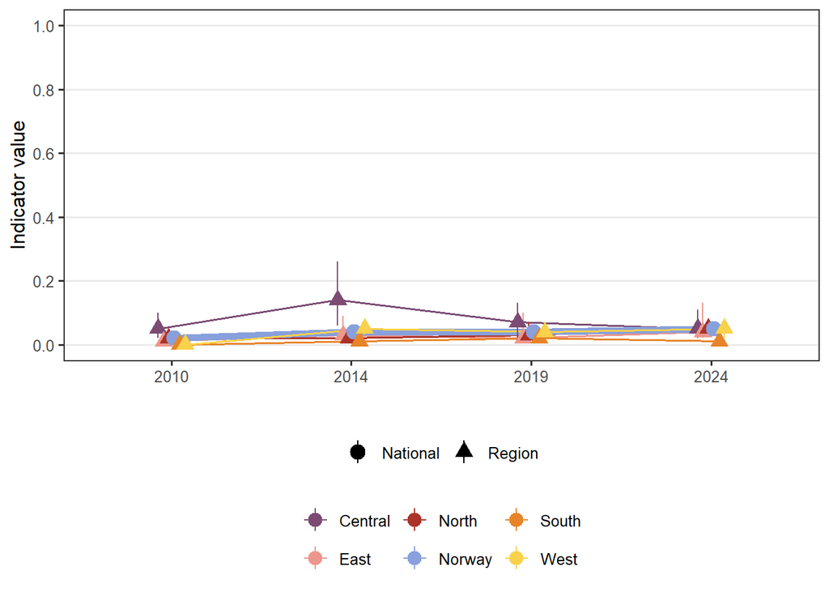

Figure 3: Indicator values for NO_AFOX_001 (arctic fox) plotted over time and for five different regions, as well as the combined national estimated. The error bars are 95% confidence intervals.

```r
ggplot(plot_data, aes(x = year, y = median, colour = part2, group = part2)) +
  geom_line(
    aes(linewidth = series_type),
    position = position_dodge(width = 0.18)
  ) +
  scale_linewidth_manual(
    values = c(National = 2, Region = 0.55),
    guide = "none"
  ) +
  geom_pointrange(
    aes(ymin = p_025, ymax = p_975, shape = series_type),
    size = 0.8,
    linewidth = 0.45,
    position = position_dodge(width = 0.18)
  ) +
  scale_colour_manual(values = region_cols, name = NULL) +
  scale_shape_manual(
    values = c(National = 19, Region = 17),
    name = NULL
  ) +
  scale_y_continuous(limits = c(0, 1), breaks = seq(0, 1, 0.2)) +
  theme_bw(base_size = 12) +
  theme(
    legend.position = "bottom",
    legend.box = "vertical",
    panel.grid.minor = element_blank(),
    panel.grid.major.x = element_blank()
  ) +
  guides(
    colour = guide_legend(
      nrow = 2,
      override.aes = list(size = 0.7, linewidth = 0.45)
    ),
    shape = guide_legend(override.aes = list(size = 0.8, linewidth = 0.45))
  ) +
  labs(y = "Indicator value", x = "")
```

```r
summary_out |>
  unite(col = "CI_95", c(p_025, p_975), sep = " - ") |>
  unite(col = "IQR", c(p_25, p_75), sep = " - ") |>
  select(
    ECT,
    Indicator,
    ID,
    "Accounting area" = part,
    Ecosystem,
    "Closing year" = year,
    "Indicator value" = median,
    "95% CI" = CI_95,
    "50% CI" = IQR
  ) |>
  knitr::kable()
```

Table 2: Indicator values and uncertainty estimates for NO_AFOX_001.

| ECT | Indicator | ID | Accounting area | Ecosystem | Closing year | Indicator value | 95% CI | 50% CI |
| --- | --- | --- | --- | --- | --- | --- | --- | --- |
| B1 | Arctic fox | NO_AFOX_001 | C | Mountains | 2010 | 0.05 | 0.02 - 0.1 | 0.03 - 0.06 |
| B1 | Arctic fox | NO_AFOX_001 | C | Mountains | 2014 | 0.14 | 0.06 - 0.26 | 0.11 - 0.19 |
| B1 | Arctic fox | NO_AFOX_001 | C | Mountains | 2019 | 0.07 | 0.02 - 0.13 | 0.04 - 0.09 |
| B1 | Arctic fox | NO_AFOX_001 | C | Mountains | 2024 | 0.05 | 0.02 - 0.11 | 0.04 - 0.07 |
| B1 | Arctic fox | NO_AFOX_001 | E | Mountains | 2010 | 0.01 | 0 - 0.01 | 0.01 - 0.01 |
| B1 | Arctic fox | NO_AFOX_001 | E | Mountains | 2014 | 0.03 | 0.01 - 0.09 | 0.02 - 0.04 |
| B1 | Arctic fox | NO_AFOX_001 | E | Mountains | 2019 | 0.02 | 0.01 - 0.1 | 0.01 - 0.02 |
| B1 | Arctic fox | NO_AFOX_001 | E | Mountains | 2024 | 0.04 | 0.02 - 0.13 | 0.03 - 0.07 |
| B1 | Arctic fox | NO_AFOX_001 | N | Mountains | 2010 | 0.02 | 0.01 - 0.04 | 0.01 - 0.02 |
| B1 | Arctic fox | NO_AFOX_001 | N | Mountains | 2014 | 0.02 | 0.02 - 0.04 | 0.02 - 0.03 |
| B1 | Arctic fox | NO_AFOX_001 | N | Mountains | 2019 | 0.03 | 0.02 - 0.07 | 0.03 - 0.04 |
| B1 | Arctic fox | NO_AFOX_001 | N | Mountains | 2024 | 0.05 | 0.03 - 0.07 | 0.04 - 0.05 |
| B1 | Arctic fox | NO_AFOX_001 | Norway | Mountains | 2010 | 0.02 | 0.01 - 0.03 | 0.01 - 0.02 |
| B1 | Arctic fox | NO_AFOX_001 | Norway | Mountains | 2014 | 0.04 | 0.03 - 0.06 | 0.04 - 0.05 |
| B1 | Arctic fox | NO_AFOX_001 | Norway | Mountains | 2019 | 0.04 | 0.03 - 0.06 | 0.03 - 0.04 |
| B1 | Arctic fox | NO_AFOX_001 | Norway | Mountains | 2024 | 0.05 | 0.03 - 0.06 | 0.04 - 0.05 |
| B1 | Arctic fox | NO_AFOX_001 | S | Mountains | 2010 | 0.00 | 0 - 0 | 0 - 0 |
| B1 | Arctic fox | NO_AFOX_001 | S | Mountains | 2014 | 0.01 | 0.01 - 0.03 | 0.01 - 0.02 |
| B1 | Arctic fox | NO_AFOX_001 | S | Mountains | 2019 | 0.02 | 0.02 - 0.02 | 0.02 - 0.02 |
| B1 | Arctic fox | NO_AFOX_001 | S | Mountains | 2024 | 0.01 | 0 - 0.03 | 0.01 - 0.02 |
| B1 | Arctic fox | NO_AFOX_001 | W | Mountains | 2010 | 0.00 | 0 - 0.01 | 0 - 0 |
| B1 | Arctic fox | NO_AFOX_001 | W | Mountains | 2014 | 0.05 | 0.03 - 0.05 | 0.05 - 0.05 |
| B1 | Arctic fox | NO_AFOX_001 | W | Mountains | 2019 | 0.04 | 0.02 - 0.07 | 0.03 - 0.05 |
| B1 | Arctic fox | NO_AFOX_001 | W | Mountains | 2024 | 0.05 | 0.02 - 0.07 | 0.04 - 0.05 |

## 11. Export file

The indicator values are exported and can be found under `data/results_NO_AFOX_001_v1.0.0.csv`.

**Export data**

```r
write.csv(out, here::here("data/results_NO_AFOX_001_v1.0.0.csv"), row.names = F)
```

## 12. Author contributions

Not relevant, as this is the work of a single author. I would, however, like to acknowledge the work of those that created the indicator on *Naturindeks* (Nater and Eriksen 2025).

**TipSession Info**

This workflow uses `renv`. Run `renv::restore()` to recreate the working environment.